# Part 3: Visualizations

### 0.0.1 Libraries

```r
library(proto)
library(gsubfn)
library(RSQLite)
library(knitr)
library(data.table)
library(plyr)
library(dplyr)
library(sqldf)
library(ggplot2)
library(RColorBrewer)
library(grid)
library(ggrepel)
library(plotly)
library(kableExtra)
```

# 1 Donut chart: Top 10 agencies with the most jobs under $10K, 2015

```r
df1<- data.frame(read.csv("agency15low.csv"),stringsAsFactors = FALSE)

df1 %>% mutate_if(is.factor, as.character) -> df1

p1 <- df1 %>%
  plot_ly(labels = ~ADDRESS, values = ~n) %>%
  add_pie(hole = 0.6) %>%
  layout(title = "Agencies with the most jobs under $10K",  showlegend = T,
         xaxis = list(showgrid = FALSE, zeroline = FALSE, showticklabels = FALSE),
         yaxis = list(showgrid = FALSE, zeroline = FALSE, showticklabels = FALSE))

p1
```

[interactive chart not shown]

# 2 Donut chart: Top 10 titles with the most jobs under $10K, 2015

```r
df2<- data.frame(read.csv("agency15low-titles.csv"),stringsAsFactors = FALSE)

df2 %>% mutate_if(is.factor, as.character) -> df2

p2 <- df2 %>%
  plot_ly(labels = ~Description, values = ~n) %>%
  add_pie(hole = 0.6) %>%
  layout(title = "Titles with the most jobs under $10K",  showlegend = T,
         xaxis = list(showgrid = FALSE, zeroline = FALSE, showticklabels = FALSE),
         yaxis = list(showgrid = FALSE, zeroline = FALSE, showticklabels = FALSE))

p2
```

[interactive chart not shown]

# 3 Donut chart: Top 10 agencies with the most jobs over $10K, 2015

```r
df3<- data.frame(read.csv("agency15high.csv"),stringsAsFactors = FALSE)

df3 %>% mutate_if(is.factor, as.character) -> df3

p3 <- df3 %>%
  plot_ly(labels = ~ADDRESS, values = ~n) %>%
  add_pie(hole = 0.6) %>%
  layout(title = "Agencies with the most jobs over $10K",  showlegend = T,
         xaxis = list(showgrid = FALSE, zeroline = FALSE, showticklabels = FALSE),
         yaxis = list(showgrid = FALSE, zeroline = FALSE, showticklabels = FALSE))

p3
```

[interactive chart not shown]

# 4 Donut chart: Top 10 titles with the most jobs over $10K, 2015

```r
df4<- data.frame(read.csv("agency15high-titles.csv"),stringsAsFactors = FALSE)

df4 %>% mutate_if(is.factor, as.character) -> df4

p4 <- df4 %>%
  plot_ly(labels = ~Description, values = ~n) %>%
  add_pie(hole = 0.6) %>%
  layout(title = "Titles with the most jobs over $10K",  showlegend = T,
         xaxis = list(showgrid = FALSE, zeroline = FALSE, showticklabels = FALSE),
         yaxis = list(showgrid = FALSE, zeroline = FALSE, showticklabels = FALSE))

p4
```

[interactive chart not shown]

# 5 Histogram: Distribution of 10K+ salaries

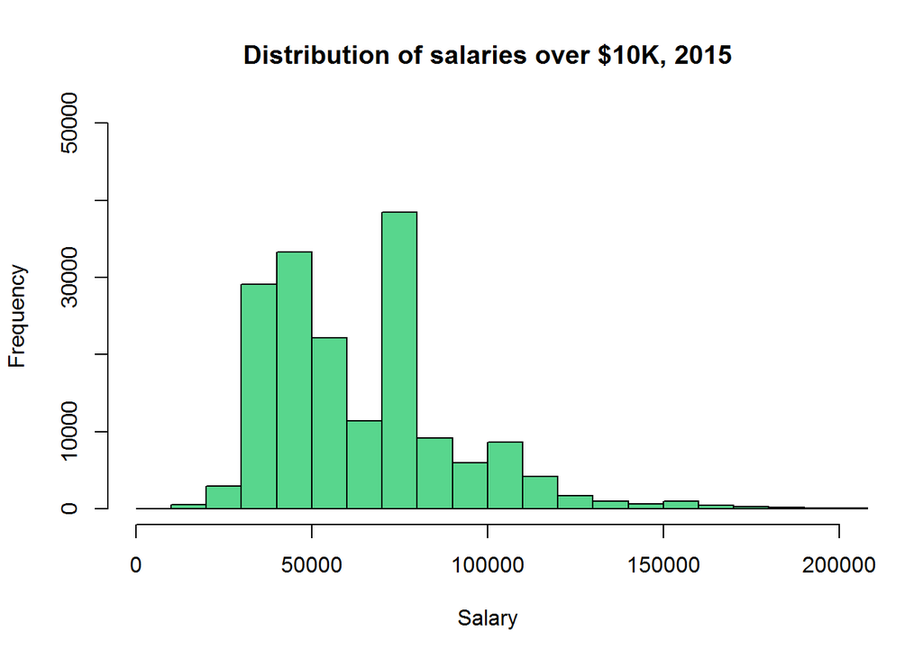

```r
df15<- data.frame(read.csv("df15.csv"),stringsAsFactors = FALSE)

hist(df15$SAL,
     main ="Distribution of salaries over $10K, 2015",
     xlab="Salary",
     border="black",
     col="#58D68D",
     xlim=c(0,200000),
     ylim=c(0,50000),
     breaks = seq(0, 350000, by = 10000)
     #prob=TRUE
     #breaks=c(0,10000,20000,30000,40000,50000,60000,70000,80000,90000,100000,110000,120000,130000,350000)
     )
```

```r
#lines(density(df15$SAL))
```

# 6 Scatterplot: Count of jobs in title vs. Average salary per title

```r
sal15a<-df15 %>%
  group_by(Description) %>%
  mutate(Count = n()) %>%
  group_by(TITLE, Description, Count) %>%
  summarise_at(vars(SAL), funs(round(mean(., na.rm=TRUE),0)  ))%>%
  arrange(desc(Count))

df5<-head(sal15a,100)

p5 <- plot_ly(
  data = df5,
  x = ~Count,
  y = ~SAL,
  type = 'scatter',
  mode = 'markers',
  hoverinfo='text',
  text = ~paste(
    'Title: ', Description,
    '<br> Employees: ', Count,
    '<br> Avg Salary: ', SAL)) %>%
  layout(title="100 most popular titles with average salary by title")
p5
```

[interactive chart not shown]

```r
p5 <- plot_ly(
  data = df5,
  x = ~Count,
  y = ~SAL,
  type = 'scatter',
  mode = 'markers',
  hoverinfo='text',
  text = ~paste(
    'Title: ', Description,
    '<br> Employees: ', Count,
    '<br> Avg Salary: ', SAL)) %>%
  layout(
    xaxis = list(range = c(0, 5000)),
    yaxis = list(range = c(0, 170000)),
    title="Popular titles with average salary by title, <5000 serving in title")
p5
```

[interactive chart not shown]

# 7 Table: Do some agencies have a greater variety of job titles available?

The following is a count of unique titles by agency.

```r
df6<-df15

df6 %>%
  group_by(ADDRESS) %>%
  summarise(count = n_distinct(TITLE))%>%
  arrange(desc(count))%>%
  top_n(20)%>%
  kable("html") %>%
  kable_styling()
```

| ADDRESS | count |
| --- | --- |
| DEPARTMENT OF HEALTH AND M | 194 |
| N.Y.C. HOUSING AUTHORITY | 184 |
| POLICE DEPARTMENT | 182 |
| DEPARTMENT OF EDUCATION | 148 |
| HRA/DEPARTMENT OF SOCIAL S | 147 |
| DEPARTMENT OF ENVIRONMENTA | 143 |
| DEPARTMENT OF TRANSPORTATI | 139 |
| FIRE DEPARTMENT | 129 |
| DEPARTMENT OF CITYWIDE ADM | 126 |
| DEPARTMENT OF CORRECTION | 110 |
| HOUSING PRESERVATION & DEV | 109 |
| DEPARTMENT OF PARKS & RECR | 107 |
| DEPARTMENT OF SANITATION | 107 |
| ADMINISTRATION FOR CHILDRE | 105 |
| DEPARTMENT OF DESIGN AND C | 93 |
| DEPARTMENT OF FINANCE | 79 |
| DEPARTMENT OF BUILDINGS | 75 |
| OFFICE OF THE COMPTROLLER | 71 |
| DEPARTMENT OF HOMELESS SER | 70 |
| DEPARTMENT OF INFORMATION | 62 |

# 8 Table: Which titles have employees across the most agencies?

The high counts here are skewed due to each Community Board being represented as a different city agency.

```r
df7<-df15

df7 %>%
  group_by(Description) %>%
  summarise(count = n_distinct(ADDRESS))%>%
  arrange(desc(count))%>%
  top_n(20)%>%
  kable("html") %>%
  kable_styling()
```

| Description | count |
| --- | --- |
| COMMUNITY ASSOCIATE | 94 |
| COMMUNITY COORDINATOR | 72 |
| COMMUNITY ASSISTANT | 64 |
| CLERICAL ASSOCIATE | 59 |
| DISTRICT MANAGER | 59 |
| PRINCIPAL ADMINISTRATIVE ASSOC | 59 |
| ADMINISTRATIVE STAFF ANALYST ( | 55 |
| COMPUTER SYSTEMS MANAGER | 51 |
| EXECUTIVE AGENCY COUNSEL | 48 |
| ADM MANAGER-NON-MGRL FRM M1/M2 | 47 |
| SECRETARY | 47 |
| ASSOCIATE STAFF ANALYST | 46 |
| COMPUTER SPECIALIST (SOFTWARE) | 40 |
| ADMINISTRATIVE PUBLIC INFORMAT | 38 |
| AGENCY ATTORNEY | 38 |
| COMPUTER ASSOC (SOFTWARE) | 38 |
| STAFF ANALYST | 37 |
| ADMINISTRATIVE MANAGER | 34 |
| COMPUTER ASSOC (OPERATIONS) | 32 |
| PROCUREMENT ANALYST | 32 |

# 9 Table: Which titles have employees across the most agencies, excluding agencies which are Community Boards?

These could be considered the most flexible titles, for employees who may want to move around across agencies while retaining their civil service title.

```r
df7a<-df7[- grep("COMMUNITY BOARD", df7$ADDRESS),]

df7a %>%
  group_by(Description) %>%
  summarise(count = n_distinct(ADDRESS))%>%
  arrange(desc(count))%>%
  top_n(20)%>%
  kable("html") %>%
  kable_styling()
```

| Description | count |
| --- | --- |
| COMMUNITY ASSOCIATE | 60 |
| PRINCIPAL ADMINISTRATIVE ASSOC | 59 |
| CLERICAL ASSOCIATE | 58 |
| COMMUNITY COORDINATOR | 56 |
| ADMINISTRATIVE STAFF ANALYST ( | 55 |
| COMPUTER SYSTEMS MANAGER | 51 |
| EXECUTIVE AGENCY COUNSEL | 48 |
| ASSOCIATE STAFF ANALYST | 46 |
| SECRETARY | 46 |
| ADM MANAGER-NON-MGRL FRM M1/M2 | 44 |
| COMMUNITY ASSISTANT | 43 |
| COMPUTER SPECIALIST (SOFTWARE) | 40 |
| ADMINISTRATIVE PUBLIC INFORMAT | 38 |
| AGENCY ATTORNEY | 38 |
| COMPUTER ASSOC (SOFTWARE) | 38 |
| STAFF ANALYST | 37 |
| ADMINISTRATIVE MANAGER | 34 |
| COMPUTER ASSOC (OPERATIONS) | 32 |
| PROCUREMENT ANALYST | 32 |
| ACCOUNTANT | 31 |

# 10 Bar Plot: Which titles have employees across the most agencies, excluding agencies which are Community Boards?

```r
# This keeps all 1089 descriptions from the original data frame
df7b<-df7a %>%
  group_by(Description) %>%
  summarise(count = n_distinct(ADDRESS))%>%
  arrange(desc(count))%>%
  top_n(10)%>%
  as.data.frame()

str(df7b)

p7 <- plot_ly(
  data = df7b,
  x = ~Description,
  y = ~count,
  type = 'bar',
  #mode = 'markers',
  hoverinfo='text',
  text = ~paste(
    'Title: ', Description,
    '<br> Employees: ', count) ) %>%
  layout(title="Titles across the most agencies, excluding Community Boards")

p7
```

```r
df7b<- data.frame(read.csv("titlesmultipleagencies.csv"),stringsAsFactors = FALSE)

df7b$Description <- factor(df7b$Description, levels = unique(df7b$Description)[order(df7b$COUNT, decreasing = TRUE)])


p7 <- plot_ly(
  data = df7b,
  x = ~Description,
  y = ~COUNT,
  type = 'bar',
  hoverinfo='text',
  color="#D7BDE2",
  text = ~paste(
    'Title: ', Description,
    '<br> Agencies: ', COUNT) ) %>%
  layout(title="Titles across the most agencies, excluding Community Boards", margin = list(b = 200), xaxis = list(tickangle = 90))

p7
```

[interactive chart not shown]

# 11 For titles across multiple agencies, do some agencies hire the same title at a higher average salary?

# 12 What titles have the most opportunities for salary increases?

## 12.1 Min and max in each title

# 13 What are the most significant changes between 2014 and 2015?

# 14 Is there a correlation between union representation and salary?

# 15 Can this data predict current job postings in 2018?

# 16 Is there a relationship between an agency’s budget and its average salaries?